# SA2 Weekly Maximum Temperature and Total Precipitation

```r
library(patchwork)
```

## Introduction

This notebook is a quick overview of the sa2_temp_precip dataset.

The dataset aggregates weekly maximum temperature and total rainfall by statistical area 2 (SA2). SA2 areas are defined by the ABS as medium sized regions representing communities which interact socially and economically. Due to the population distribution in Australia, this means that they vary widely in size.

For instance, these are the SA2 areas for the Australian Capital Territory:

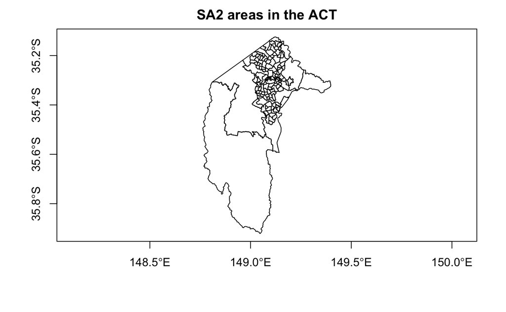

```r
sa2_act <- sa2 %>%
  filter(STE_NAME16 == "Australian Capital Territory")

plot(sa2_act$geometry, axes = TRUE)
title("SA2 areas in the ACT")
```

Version 1 of the Australian Gridded Climate Data (also known as the Australian Water Availability Project (AWAP)) is used to access a historical time series of climate variables over all of Australia. Total precipitation and maximum temperature data is available in a raster file with cells of size 0.05 degrees square (around 5 km square).

On January 8 2018 the precipitation across the ACT looks like this (this day was chosen simply because their is a lot of variation in rainfall):

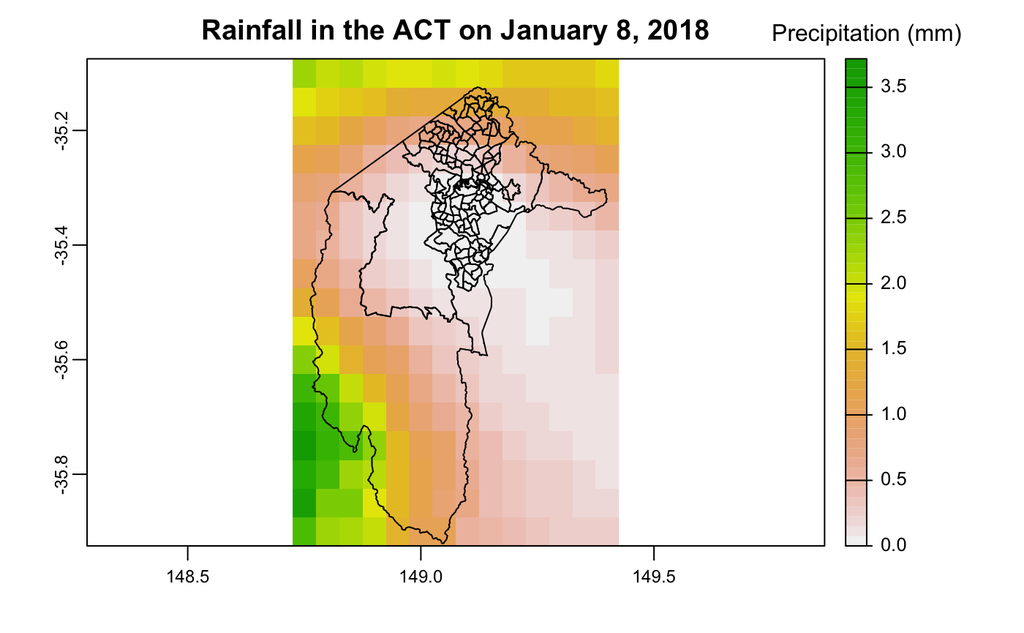

We could also make a similar plot for temperature data on the same day:

```r
tmax_2018_act <- crop(tmax_2018, sa2_act, snap = "out")

plot(tmax_2018_act[[8]], plg = list(title = "Temperature (deg C)"))
plot(sa2_act$geometry, add = TRUE)
```

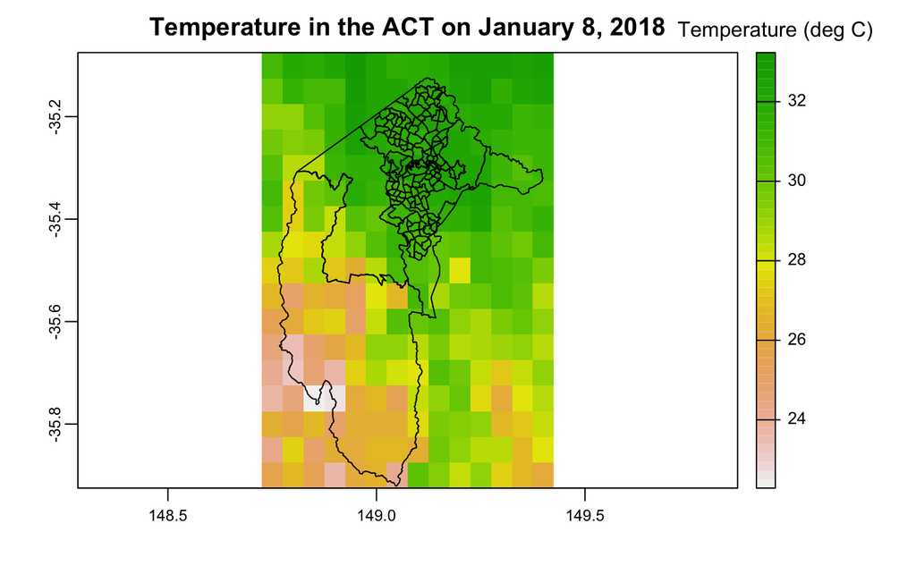

```r
title("Temperature in the ACT on January 8, 2018")
```

## Method

The method used to create the final data set depends upon identifying which raster squares overlap with which SA2 areas, and then applying a summary function to the raster values. The result is then aggregated by week.

In the case of total weekly rainfall, this means that the rainfall in each cell is first multiplied by the cell area to get a volume of rainfall. We then take a weighted sum of these rainfalls by the amount each cell overlaps with each SA2 area. The final value is divided by the area of the SA2 region to return the output back to mm. The rainfall in mm is then summed in each week.

Calculating the maximum temperature in each SA2 is simpler - we just need to find the highest cell value in each SA2 area (regardless of overlap). We can then take the maximum again by week to get a weekly maximum temperature.

Note that weeks have simply been defined as 7 day periods starting on Mondays. As we are interested in the years 2000 - 2018, a result of this definition of weeks is that the first week has to start in in 1999, and the last one ends in 2019.

The output looks something like this, where weekly_precip is in mm and weekly_tmax is in degress celcius (this is the data for Majura only):

```r
majura_temp_precip <- sa2_temp_precip %>%
  filter(SA2_NAME16 == "Majura")

majura_temp_precip
```

| SA2_MAIN16 | SA2_5DIG16 | SA2_NAME16 | AREASQKM16 | week_starting | weekly_precip | weekly_tmax |
| --- | --- | --- | --- | --- | --- | --- |
| 801031115 | 81115 | Majura | 89.692 | 1999-12-27 | 74.0 | 24.7 |
| 801031115 | 81115 | Majura | 89.692 | 2000-01-03 | 0.6 | 27.6 |
| 801031115 | 81115 | Majura | 89.692 | 2000-01-10 | 0.1 | 30.6 |
| 801031115 | 81115 | Majura | 89.692 | 2000-01-17 | 0.2 | 36.2 |
| 801031115 | 81115 | Majura | 89.692 | 2000-01-24 | 35.0 | 26.2 |
| 801031115 | 81115 | Majura | 89.692 | 2000-01-31 | 0.0 | 34.7 |
| 801031115 | 81115 | Majura | 89.692 | 2000-02-07 | 2.5 | 34.1 |
| 801031115 | 81115 | Majura | 89.692 | 2000-02-14 | 0.0 | 33.0 |
| 801031115 | 81115 | Majura | 89.692 | 2000-02-21 | 11.3 | 32.2 |
| 801031115 | 81115 | Majura | 89.692 | 2000-02-28 | 0.0 | 34.1 |

[output cut: 983 more lines]

```r
p1 <- majura_temp_precip %>%
  ggplot(aes(x = week_starting, y = weekly_precip)) +
  geom_line()

p2 <- majura_temp_precip %>%
  ggplot(aes(x = week_starting, y = weekly_tmax)) +
  geom_line()

p1 / p2 + plot_annotation("Weekly maximum temperature and total precipitation in the Majura SA2 area")
```

[output not shown]

## Assumptions and limitations

- The data set used (AWAP) was developed for looking at long term climate trends. As such, it only used gauge data maintained by the BOM. More accurate data could be obtained by including remote sensing or radar data.
- Rainfall data represents precipitation in the 24-hour period to 0900 local time. When aggregated by week, this means that weeks actually start on at 9 AM on a Monday rather than midnight.
- The RMSEs for temparature are typically between 0.5 and 1 degree celcius. For rainfall, the RMSE is typically between 3 and 4 mm. The analysis is less accurate where the station network is sparse (remote areas) or where there is a sharp climatic gradient (e.g. coastal areas).
- The continuous temperature and precipitation surfaces have been generated using often sparse gauge data. As a result, the maximum temperature identified in a raster cell exceedes the maximum value at a gauge site.

For more information on the AWAP data set, see

Jones, D, W Wang, and R Fawcett. “High-Quality Spatial Climate Data-Sets for Australia.” Australian Meteorological and Oceanographic Journal 58, no. 04 (December 2009): 233–48. https://doi.org/10.22499/2.5804.003.